title: “CS1950_Week05_GMD” author: “Hunsi Jayaprakash” date: “2/4/2022” output: html_document —

## Load packages

```r
library(tidyverse)
file_name <- ("https://raw.githubusercontent.com/jyurko/cs_1950_brain_proj/main/KLU_APC2_Master_2021_07_07.csv?token=GHSAT0AAAAAABQQ7BMCJN2DI3DFUBFY6DSMYQXTN3A")
df <- readr::read_csv(file_name,col_names = TRUE)
```

## Check unique identifiers

The number of rows associated with each `Vault_Scan_ID`.

```r
df %>%
  count(Vault_Scan_ID)
```

```
## # A tibble: 190 x 2
##    Vault_Scan_ID     n
##            <dbl> <int>
##  1        800569     1
##  2        800570     1
##  3        800571     1
##  4        800572     1
##  5        800573     1
##  6        800574     1
##  7        800575     1
##  8        800684     1
##  9        800685     1
## 10        800686     1
## # ... with 180 more rows
```

The count for the number of rows associated with each `Vault_Scan_ID`.

```r
df %>%
  count(Vault_Scan_ID) %>%
  count(n, name = "times_occuring")
```

```
## # A tibble: 2 x 2
##       n times_occuring
##   <int>          <int>
## 1     1            189
## 2     2              1
```

So there is one `Vault_Scan_ID` that occurs twice, check which one:  
Vault_Scan_ID = 802688 occurs twice

```r
df %>%
  count(Vault_Scan_ID) %>%
  filter(n > 1)
```

```
## # A tibble: 1 x 2
##   Vault_Scan_ID     n
##           <dbl> <int>
## 1        802688     2
```

Look at the rows associated with that `Vault_Scan_ID` value along with the `Vault_UID` value.

```r
vault_id_focus <- df %>%
  count(Vault_Scan_ID) %>%
  filter(n > 1) %>%
  pull(Vault_Scan_ID)
df %>%
  select(Vault_Scan_ID, Vault_UID) %>%
  filter(Vault_Scan_ID %in% vault_id_focus)
```

```
## # A tibble: 2 x 2
##   Vault_Scan_ID Vault_UID
##           <dbl>     <dbl>
## 1        802688    900534
## 2        802688    900534
```

Include columns involving date in the column name.

```r
df %>%
  select(Vault_Scan_ID, Vault_UID, ends_with("_date", ignore.case = TRUE)) %>%
  filter(Vault_Scan_ID %in% vault_id_focus)
```

```
## # A tibble: 2 x 7
##   Vault_Scan_ID Vault_UID MR_Scan_Date        PET_Scan_Date Cog_Test_Date
##           <dbl>     <dbl> <dttm>              <chr>         <chr>
## 1        802688    900534 2015-11-23 00:00:00 NaN           NaN
## 2        802688    900534 2015-11-23 00:00:00 NaN           NaN
## # ... with 2 more variables: PIB_Scan_Date <dttm>, FDG_Scan_Date <dttm>
```

Check columns that contain “ID” in the column name.

```r
df %>%
  select(Vault_Scan_ID, Vault_UID, contains("ID", ignore.case = FALSE)) %>%
  filter(Vault_Scan_ID %in% vault_id_focus)
```

```
## # A tibble: 2 x 5
##   Vault_Scan_ID Vault_UID GPNID_VisitNum Nebes_ID UniqueID
##           <dbl>     <dbl> <chr>             <dbl> <chr>
## 1        802688    900534 0134DL108         16037 0134DL
## 2        802688    900534 0134DL108         16037 0134DL
```

**What other identifiers should be considered here??** Identifiers to include : age, sex, race, education , APOE_allele, PiB Regional values Left , PiB regional Right, PiB Global Values , GMD regional Left, GMD right, GMD global, FDG Regional left, FDG regional Right, FDG global

How many unique people are there? And how many rows are associated with each unique person? n = 93 ; max number of rows associated with a unique person is 4

```r
df %>%
  count(Vault_UID) %>%
  arrange(desc(n))
```

```
## # A tibble: 93 x 2
##    Vault_UID     n
##        <dbl> <int>
##  1    900643     4
##  2    900645     4
##  3    900719     4
##  4    900721     4
##  5    901382     4
##  6    901383     4
##  7    900534     3
##  8    900536     3
##  9    900644     3
## 10    900648     3
## # ... with 83 more rows
```

```r
df %>%
  count(Vault_UID) %>%
  count(n, name='times_occurs')
```

```
## # A tibble: 4 x 2
##       n times_occurs
##   <int>        <int>
## 1     1           33
## 2     2           28
## 3     3           26
## 4     4            6
```

## GMD Exploration

Extract the GMD related variables along with the unique identifiers.

**Will need to do this again based on the unique identifiers that should be included.**

```r
gmd_regional_df <- df %>% select(Vault_Scan_ID, Vault_UID, MR_Scan_Date, starts_with("GMD_"))
gmd_regional_df %>% glimpse()
```

```
## Rows: 191
## Columns: 55
## $ Vault_Scan_ID                     <dbl> 800569, 800570, 800571, 800572, 8005~
## $ Vault_UID                         <dbl> 900534, 900535, 900536, 900537, 9005~
## $ MR_Scan_Date                      <dttm> 2010-06-25, 2010-07-08, 2010-07-13,~
## $ GMD_regional_Caudate_L            <dbl> 0.02373456, 0.01969476, 0.03167635, ~
## $ GMD_regional_Caudate_R            <dbl> 0.01059574, 0.01198194, 0.02083026, ~
## $ GMD_regional_Frontal_Inf_Oper_L   <dbl> 0.03150954, 0.02736514, 0.04106963, ~
## $ GMD_regional_Frontal_Inf_Oper_R   <dbl> 0.04812844, 0.04235988, 0.06693525, ~
## $ GMD_regional_Frontal_Inf_Orb_2_L  <dbl> 0.03049385, 0.01609450, 0.03930057, ~
## $ GMD_regional_Frontal_Inf_Orb_2_R  <dbl> 0.05045992, 0.04320490, 0.06409519, ~
## $ GMD_regional_Frontal_Inf_Tri_L    <dbl> 0.01842660, 0.01493411, 0.02542379, ~
## $ GMD_regional_Frontal_Inf_Tri_R    <dbl> 0.01736503, 0.01511288, 0.02623209, ~
## $ GMD_regional_Frontal_Med_Orb_L    <dbl> 0.02545738, 0.01804623, 0.03116225, ~
## $ GMD_regional_Frontal_Med_Orb_R    <dbl> 0.02621201, 0.01584955, 0.03120604, ~
```

[output cut: 42 more lines]

```r
gmd_global_df <- df %>% select(Vault_Scan_ID, Vault_UID, starts_with("FS_"))
gmd_global_df %>% glimpse()
```

```
## Rows: 191
## Columns: 137
## $ Vault_Scan_ID                         <dbl> 800569, 800570, 800571, 800572, ~
## $ Vault_UID                             <dbl> 900534, 900535, 900536, 900537, ~
## $ FS_lh_bankssts_volume                 <dbl> 2647, 2881, 2659, 1075, 1723, 22~
## $ FS_lh_caudalanteriorcingulate_volume  <dbl> 1973, 1581, 1567, 1130, 1222, 17~
## $ FS_lh_caudalmiddlefrontal_volume      <dbl> 4518, 5537, 6326, 3913, 6885, 40~
## $ FS_lh_cuneus_volume                   <dbl> 2832, 2401, 3014, 1937, 2951, 21~
## $ FS_lh_entorhinal_volume               <dbl> 1577, 1587, 1771, 1736, 1743, 17~
## $ FS_lh_fusiform_volume                 <dbl> 9599, 8118, 9008, 4970, 8893, 86~
## $ FS_lh_inferiorparietal_volume         <dbl> 10224, 9959, 10369, 6589, 9881, ~
## $ FS_lh_inferiortemporal_volume         <dbl> 7515, 9014, 7804, 6772, 10503, 7~
## $ FS_lh_isthmuscingulate_volume         <dbl> 2852, 2061, 2483, 1558, 2265, 21~
## $ FS_lh_lateraloccipital_volume         <dbl> 10679, 6358, 10744, 8682, 9404, ~
## $ FS_lh_lateralorbitofrontal_volume     <dbl> 6915, 5817, 6147, 4606, 6621, 52~
```

[output cut: 124 more lines]

Focusing on the variables with `GMD_regional_` naming patterns.

```r
gmd_regional_wf <- gmd_regional_df %>%
  select(starts_with("Vault"), MR_Scan_Date, starts_with("GMD_regional"))
gmd_regional_wf %>% glimpse()
```

```
## Rows: 191
## Columns: 55
## $ Vault_Scan_ID                     <dbl> 800569, 800570, 800571, 800572, 8005~
## $ Vault_UID                         <dbl> 900534, 900535, 900536, 900537, 9005~
## $ MR_Scan_Date                      <dttm> 2010-06-25, 2010-07-08, 2010-07-13,~
## $ GMD_regional_Caudate_L            <dbl> 0.02373456, 0.01969476, 0.03167635, ~
## $ GMD_regional_Caudate_R            <dbl> 0.01059574, 0.01198194, 0.02083026, ~
## $ GMD_regional_Frontal_Inf_Oper_L   <dbl> 0.03150954, 0.02736514, 0.04106963, ~
## $ GMD_regional_Frontal_Inf_Oper_R   <dbl> 0.04812844, 0.04235988, 0.06693525, ~
## $ GMD_regional_Frontal_Inf_Orb_2_L  <dbl> 0.03049385, 0.01609450, 0.03930057, ~
## $ GMD_regional_Frontal_Inf_Orb_2_R  <dbl> 0.05045992, 0.04320490, 0.06409519, ~
## $ GMD_regional_Frontal_Inf_Tri_L    <dbl> 0.01842660, 0.01493411, 0.02542379, ~
## $ GMD_regional_Frontal_Inf_Tri_R    <dbl> 0.01736503, 0.01511288, 0.02623209, ~
## $ GMD_regional_Frontal_Med_Orb_L    <dbl> 0.02545738, 0.01804623, 0.03116225, ~
## $ GMD_regional_Frontal_Med_Orb_R    <dbl> 0.02621201, 0.01584955, 0.03120604, ~
```

[output cut: 42 more lines]

Check number of missings per column.

```r
gmd_regional_wf %>% purrr::map_dbl(~sum(is.na(.)))
```

```
##                     Vault_Scan_ID                         Vault_UID
##                                 0                                 0
##                      MR_Scan_Date            GMD_regional_Caudate_L
##                                 0                                24
##            GMD_regional_Caudate_R   GMD_regional_Frontal_Inf_Oper_L
##                                24                                24
##   GMD_regional_Frontal_Inf_Oper_R  GMD_regional_Frontal_Inf_Orb_2_L
##                                24                                24
##  GMD_regional_Frontal_Inf_Orb_2_R    GMD_regional_Frontal_Inf_Tri_L
##                                24                                24
##    GMD_regional_Frontal_Inf_Tri_R    GMD_regional_Frontal_Med_Orb_L
##                                24                                24
##    GMD_regional_Frontal_Med_Orb_R      GMD_regional_Frontal_Mid_2_L
##                                24                                24
##      GMD_regional_Frontal_Mid_2_R      GMD_regional_Frontal_Sup_2_L
##                                24                                24
##      GMD_regional_Frontal_Sup_2_R GMD_regional_Frontal_Sup_Medial_L
##                                24                                24
## GMD_regional_Frontal_Sup_Medial_R           GMD_regional_Fusiform_L
##                                24                                24
##           GMD_regional_Fusiform_R             GMD_regional_Heschl_L
##                                24                                24
##             GMD_regional_Heschl_R             GMD_regional_Insula_L
##                                24                                24
##             GMD_regional_Insula_R             GMD_regional_OFCant_L
##                                24                                24
##             GMD_regional_OFCant_R           GMD_regional_Pallidum_L
##                                24                                24
##           GMD_regional_Pallidum_R    GMD_regional_ParaHippocampal_L
##                                24                                24
##    GMD_regional_ParaHippocampal_R       GMD_regional_Parietal_Inf_L
##                                24                                24
##       GMD_regional_Parietal_Inf_R        GMD_regional_Postcentral_L
##                                24                                24
##        GMD_regional_Postcentral_R         GMD_regional_Precentral_L
##                                24                                24
##         GMD_regional_Precentral_R            GMD_regional_Putamen_L
##                                24                                24
##            GMD_regional_Putamen_R             GMD_regional_Rectus_L
##                                24                                24
##             GMD_regional_Rectus_R      GMD_regional_Rolandic_Oper_L
##                                24                                24
##      GMD_regional_Rolandic_Oper_R      GMD_regional_SupraMarginal_L
##                                24                                24
##      GMD_regional_SupraMarginal_R       GMD_regional_Temporal_Inf_L
##                                24                                24
##       GMD_regional_Temporal_Inf_R       GMD_regional_Temporal_Mid_L
##                                24                                24
##       GMD_regional_Temporal_Mid_R  GMD_regional_Temporal_Pole_Mid_L
##                                24                                24
##  GMD_regional_Temporal_Pole_Mid_R  GMD_regional_Temporal_Pole_Sup_L
##                                24                                24
##  GMD_regional_Temporal_Pole_Sup_R       GMD_regional_Temporal_Sup_L
##                                24                                24
##       GMD_regional_Temporal_Sup_R
##                                24
```

Distribution of the GMD regional variables across all rows. This ignores any grouping by people.

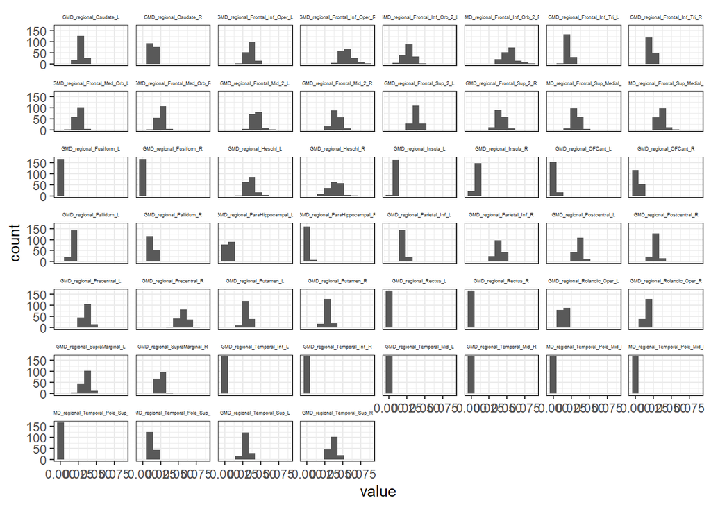

```r
gmd_regional_wf %>%
  tibble::rowid_to_column() %>%
  pivot_longer(cols = starts_with("GMD_regional")) %>%
  ggplot(mapping = aes(x = value)) +
  geom_histogram(bins = 10) +
  facet_wrap(~name) +
  theme_bw() +
  theme(strip.background = element_blank(),
        strip.text = element_text(size = 3.5))
```

Use boxplots instead.

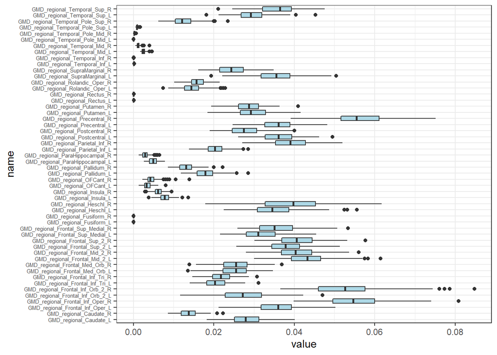

```r
gmd_regional_wf %>%
  tibble::rowid_to_column() %>%
  pivot_longer(cols = starts_with("GMD_regional")) %>%
  ggplot(mapping = aes(y = name, x = value)) +
  geom_boxplot(fill = 'light blue') +
  theme_bw() +
  theme(axis.text.y = element_text(size = 5.5))
```

Start to parse the regional variable names.

Create a helper function to separate the variable names based on the `'_'` pattern. The helper function is required because the number of underscores is not consistent across the regional names.

```r
my_separate <- function(the_data, num_us)
{
  names_keep <- the_data %>% select(-name) %>% names()

  the_data %>%
    tidyr::separate(name,
                    c("result_type", "regional_word",
                      sprintf("name_%02d", 1:(num_us-1))),
                    sep = "_") %>%
    rename(!!!c("side_name" = sprintf("name_%02d", num_us-1))) %>%
    tidyr::unite("region_name",
                 sprintf("name_%02d", 1:(num_us-2)),
                 sep = "_") %>%
    select(all_of(c(names_keep,
                    "result_type", "region_name", "side_name")))
}
```

Apply the helper function based on the number of underscores to create the long-format data.

```r
gmd_regional_lf <- gmd_regional_wf %>%
  tibble::rowid_to_column() %>%
  pivot_longer(cols = starts_with("GMD_regional")) %>%
  mutate(num_underscores = stringr::str_count(name, pattern = "_")) %>%
  group_by(num_underscores) %>%
  tidyr::nest() %>%
  mutate(ready_data = purrr::map2(data, num_underscores, my_separate)) %>%
  select(num_underscores, ready_data) %>%
  tidyr::unnest(ready_data) %>%
  ungroup()
```

Check the unique region names and the number of rows associated with each region name.

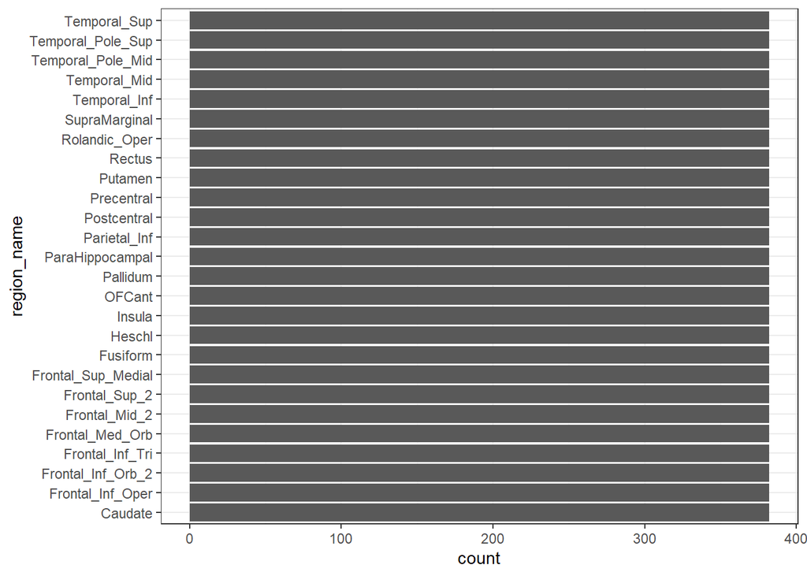

```r
gmd_regional_lf %>%
  ggplot(mapping = aes(y = region_name)) +
  geom_bar() +
  theme_bw()
```

Include the side.

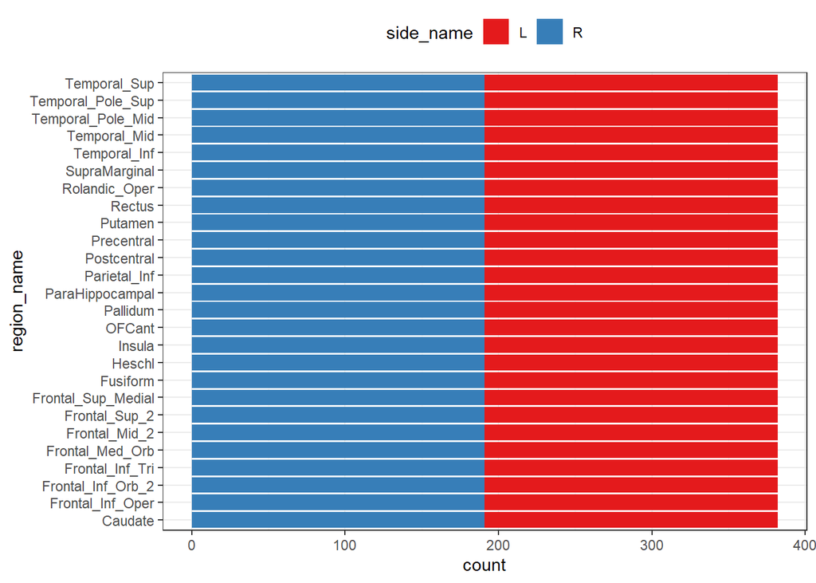

```r
gmd_regional_lf %>%
  ggplot(mapping = aes(y = region_name)) +
  geom_bar(mapping = aes(fill = side_name)) +
  scale_fill_brewer(palette = "Set1") +
  theme_bw() +
  theme(legend.position = 'top')
```

Distributions of GMD values per region and side. Note the x-axis scales are the same in each facet.

Some regions have larger left hemispheres in cortical volume.

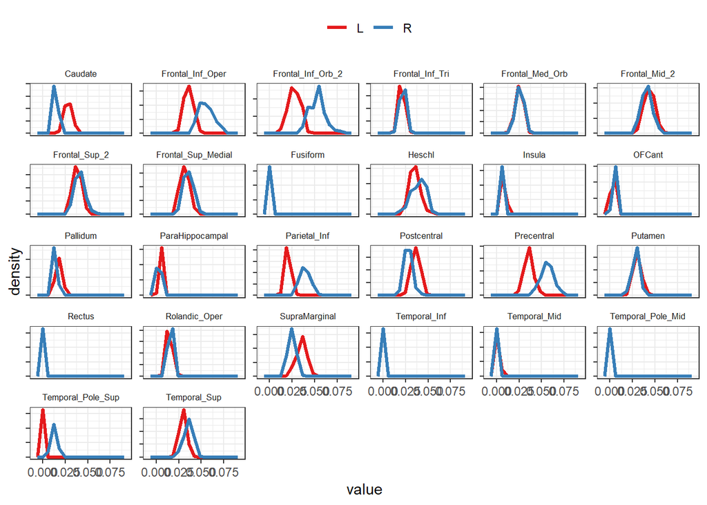

```r
gmd_regional_lf %>%
  ggplot(mapping = aes(x = value)) +
  geom_freqpoly(mapping = aes(color = side_name,
                              group = interaction(region_name,
                                                  side_name),
                              y = stat(density)),
                size = 1.2,
                bins = 15) +
  facet_wrap(~region_name, scales = "free_y") +
  scale_color_brewer("", palette = "Set1") +
  theme_bw() +
  theme(legend.position = 'top',
        axis.text.y = element_blank(),
        strip.background = element_blank(),
        strip.text = element_text(size = 6.5))
```

Allow the x-axis scales to vary across facets. kept the bin number constant zoom in to see the plot

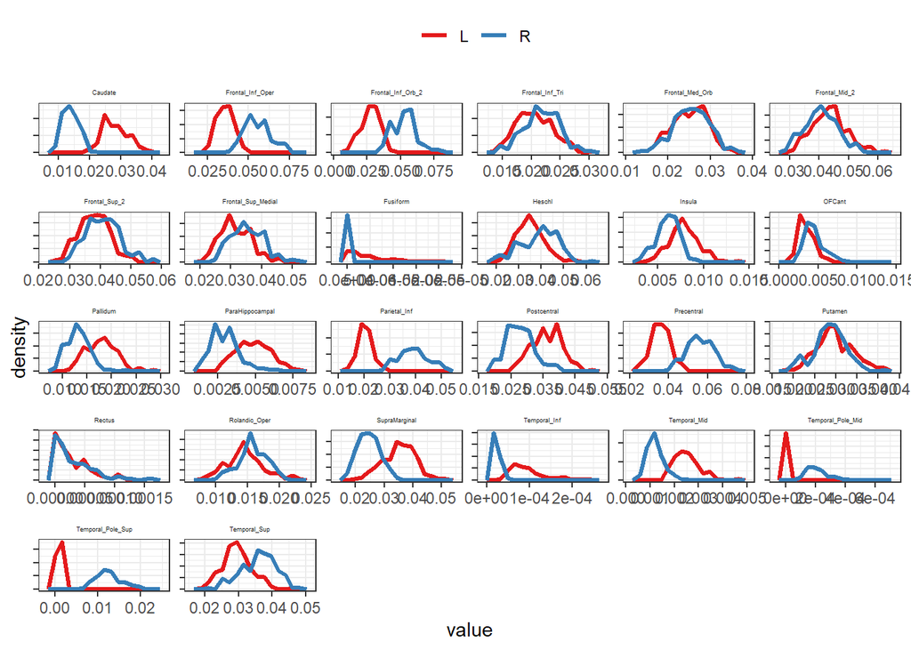

```r
gmd_regional_lf %>%
  ggplot(mapping = aes(x = value)) +
  geom_freqpoly(mapping = aes(color = side_name,
                              group = interaction(region_name,
                                                  side_name),
                              y = stat(density)),
                size = 1.2,
                bins = 15) +
  facet_wrap(~region_name, scales = "free") +
  scale_color_brewer("", palette = "Set1") +
  theme_bw() +
  theme(legend.position = 'top',
        axis.text.y = element_blank(),
        strip.background = element_blank(),
        strip.text = element_text(size = 3.5))
```

Check the behavior of the repeated observations per person. The x-axis corresponds to a unique `Vault_UID` but the axis text has been turned off to make the plots easier to read.

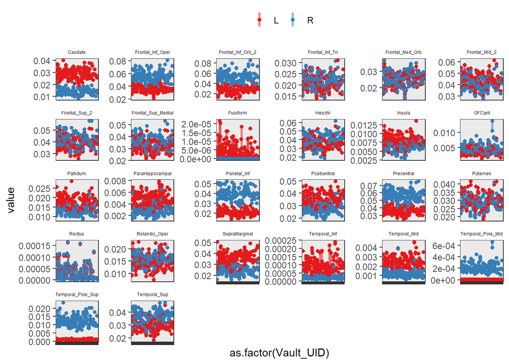

```r
gmd_regional_lf %>%
  ggplot(mapping = aes(x = as.factor(Vault_UID), y = value)) +
  stat_summary(geom = 'linerange',
               fun.min = 'min', fun.max = 'max',
               mapping = aes(group = interaction(Vault_UID,
                                                 region_name,
                                                 side_name),
                             color = side_name),
               position = position_dodge(0.1),
               size = 1.2, alpha = 0.5) +
  geom_point(mapping = aes(group = interaction(Vault_UID,
                                               region_name,
                                               side_name),
                           color = side_name),
             position = position_dodge(0.1)) +
  facet_wrap(~region_name, scales = 'free_y') +
  scale_color_brewer("", palette = "Set1") +
  theme_bw() +
  theme(legend.position = 'top',
        axis.text.x = element_blank(),
        strip.background = element_blank(),
        strip.text = element_text(size = 4.5))
```

Focused on a single region.

Region: Frontal_Sup_2 since it showed significant FDG and PiB asymmetry. Did not show significant GMD asymmetry.

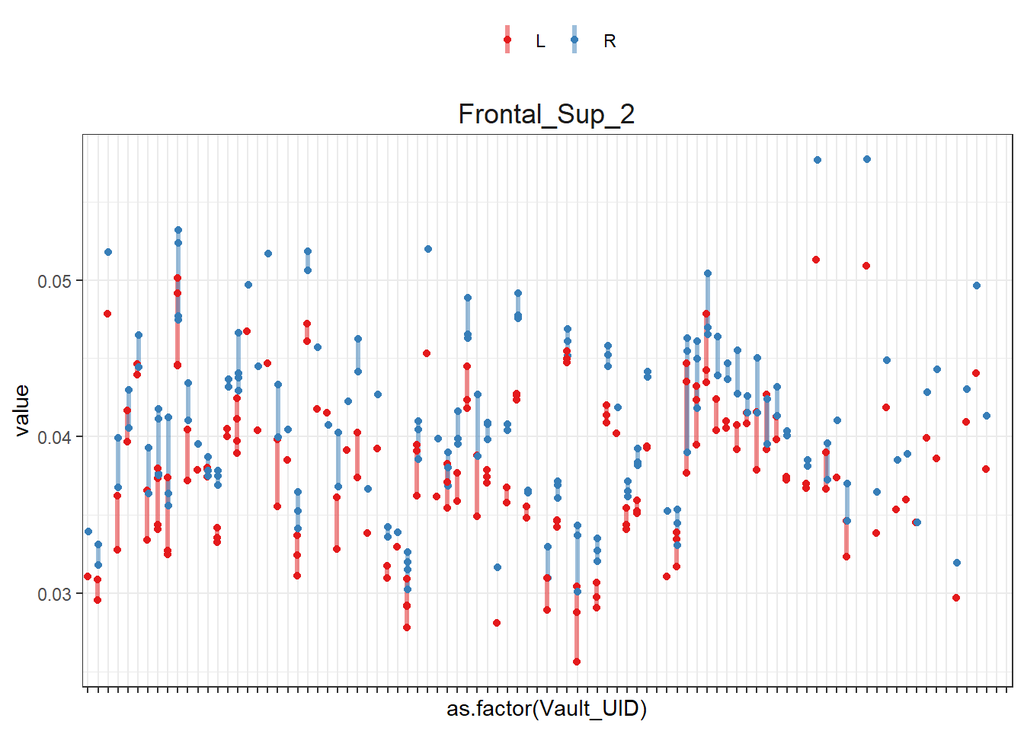

```r
gmd_regional_lf %>%
  filter(region_name %in% 'Frontal_Sup_2') %>%
  ggplot(mapping = aes(x = as.factor(Vault_UID), y = value)) +
  stat_summary(geom = 'linerange',
               fun.min = 'min', fun.max = 'max',
               mapping = aes(group = interaction(Vault_UID,
                                                 region_name,
                                                 side_name),
                             color = side_name),
               position = position_dodge(0.2),
               size = 1.2, alpha = 0.5) +
  geom_point(mapping = aes(group = interaction(Vault_UID,
                                               region_name,
                                               side_name),
                           color = side_name),
             position = position_dodge(0.2)) +
  facet_wrap(~region_name, scales = 'free_y') +
  scale_color_brewer("", palette = "Set1") +
  theme_bw() +
  theme(legend.position = 'top',
        axis.text.x = element_blank(),
        strip.background = element_blank(),
        strip.text = element_text(size = 13.5))
```

Focused on a single region and one person.

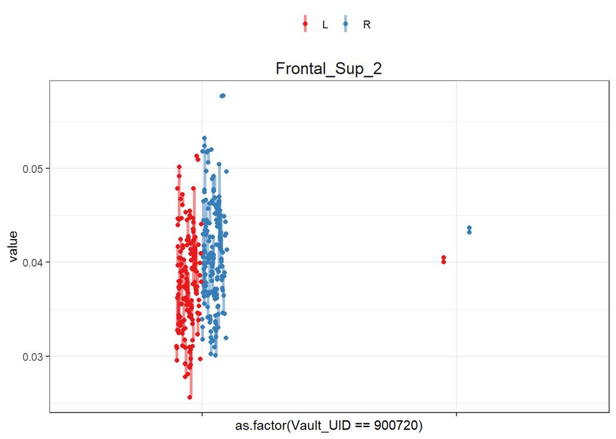

```r
gmd_regional_lf %>%
  filter(region_name %in% 'Frontal_Sup_2') %>%
  ggplot(mapping = aes(x = as.factor(Vault_UID == 900720), y = value)) +
  stat_summary(geom = 'linerange',
               fun.min = 'min', fun.max = 'max',
               mapping = aes(group = interaction(Vault_UID,
                                                 region_name,
                                                 side_name),
                             color = side_name),
               position = position_dodge(0.2),
               size = 1.2, alpha = 0.5) +
  geom_point(mapping = aes(group = interaction(Vault_UID,
                                               region_name,
                                               side_name),
                           color = side_name),
             position = position_dodge(0.2)) +
  facet_wrap(~region_name, scales = 'free_y') +
  scale_color_brewer("", palette = "Set1") +
  theme_bw() +
  theme(legend.position = 'top',
        axis.text.x = element_blank(),
        strip.background = element_blank(),
        strip.text = element_text(size = 13.5))
```

**Do you want to focus on a single person?**

The filter should be applied before the ggplot() call.

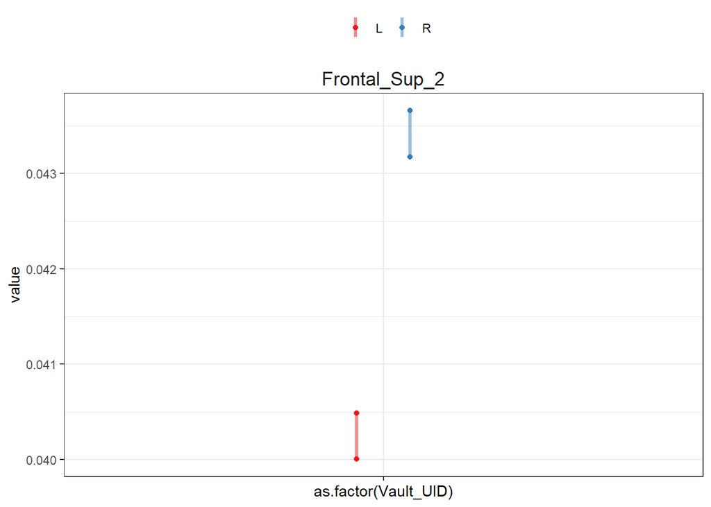

```r
gmd_regional_lf %>%
  filter(region_name %in% 'Frontal_Sup_2') %>%
  filter(Vault_UID %in% c(900720)) %>%
  ggplot(mapping = aes(x = as.factor(Vault_UID), y = value)) +
  stat_summary(geom = 'linerange',
               fun.min = 'min', fun.max = 'max',
               mapping = aes(group = interaction(Vault_UID,
                                                 region_name,
                                                 side_name),
                             color = side_name),
               position = position_dodge(0.2),
               size = 1.2, alpha = 0.5) +
  geom_point(mapping = aes(group = interaction(Vault_UID,
                                               region_name,
                                               side_name),
                           color = side_name),
             position = position_dodge(0.2)) +
  facet_wrap(~region_name, scales = 'free_y') +
  scale_color_brewer("", palette = "Set1") +
  theme_bw() +
  theme(legend.position = 'top',
        axis.text.x = element_blank(),
        strip.background = element_blank(),
        strip.text = element_text(size = 13.5))
```

```r
gmd_spread <- gmd_regional_df%>%
  select(starts_with("GMD_regional_Frontal_Sup_2"))
gmd_spread%>% summary()
```

```
##  GMD_regional_Frontal_Sup_2_L GMD_regional_Frontal_Sup_2_R
##  Min.   :0.02561              Min.   :0.03011
##  1st Qu.:0.03438              1st Qu.:0.03689
##  Median :0.03785              Median :0.04057
##  Mean   :0.03791              Mean   :0.04086
##  3rd Qu.:0.04133              3rd Qu.:0.04445
##  Max.   :0.05130              Max.   :0.05771
##  NA's   :24                   NA's   :24
```

```r
gmd_regional_lf %>% bind_rows() %>%
  group_by(Vault_UID) %>% summarise(num_rows = n(), avg_x = mean(value), .groups = 'drop') %>% summary(avg_x)
```

```
##    Vault_UID         num_rows         avg_x
##  Min.   :900534   Min.   : 52.0   Min.   :0.01569
##  1st Qu.:901060   1st Qu.: 52.0   1st Qu.:0.01988
##  Median :901470   Median :104.0   Median :0.02137
##  Mean   :901533   Mean   :106.8   Mean   :0.02151
##  3rd Qu.:902081   3rd Qu.:156.0   3rd Qu.:0.02324
##  Max.   :903110   Max.   :208.0   Max.   :0.03029
##                                   NA's   :21
```

## Vault_UID ranges

Calculate the range of the value for each person in each region per side. Show for a single region and person. First isolate that person and region.

```r
gmd_regional_lf %>%
  filter(region_name %in% 'Frontal_Sup_2') %>%
  filter(Vault_UID %in% c(900720)) %>%
  select(Vault_Scan_ID, Vault_UID, MR_Scan_Date, result_type, region_name, side_name, value)
```

```
## # A tibble: 6 x 7
##   Vault_Scan_ID Vault_UID MR_Scan_Date        result_type region_name  side_name
##           <dbl>     <dbl> <dttm>              <chr>       <chr>        <chr>
## 1        800761    900720 2011-03-01 00:00:00 GMD         Frontal_Sup~ L
## 2        800761    900720 2011-03-01 00:00:00 GMD         Frontal_Sup~ R
## 3        802207    900720 2013-05-10 00:00:00 GMD         Frontal_Sup~ L
## 4        802207    900720 2013-05-10 00:00:00 GMD         Frontal_Sup~ R
## 5        802576    900720 2015-03-02 00:00:00 GMD         Frontal_Sup~ L
## 6        802576    900720 2015-03-02 00:00:00 GMD         Frontal_Sup~ R
## # ... with 1 more variable: value <dbl>
```

Then group and summarize.

```r
gmd_regional_lf %>%
  filter(region_name %in% 'Frontal_Sup_2') %>%
  filter(Vault_UID %in% c(900720)) %>%
  group_by(result_type, region_name, side_name, Vault_UID) %>%
  summarise(num_rows = n(),
            num_missing = sum(is.na(value)),
            num_scans = n_distinct(Vault_Scan_ID),
            first_scan = min(MR_Scan_Date),
            last_scan = max(MR_Scan_Date),
            avg_value = mean(value, na.rm = TRUE),
            min_value = min(value, na.rm = TRUE),
            max_value = max(value, na.rm = TRUE),
            .groups = 'drop')
```

```
## # A tibble: 2 x 12
##   result_type region_name   side_name Vault_UID num_rows num_missing num_scans
##   <chr>       <chr>         <chr>         <dbl>    <int>       <int>     <int>
## 1 GMD         Frontal_Sup_2 L            900720        3           1         3
## 2 GMD         Frontal_Sup_2 R            900720        3           1         3
## # ... with 5 more variables: first_scan <dttm>, last_scan <dttm>,
## #   avg_value <dbl>, min_value <dbl>, max_value <dbl>
```

Calculate the range and show the summary stats for this one person and region.

```r
gmd_regional_lf %>%
  filter(region_name %in% 'Frontal_Sup_2') %>%
  filter(Vault_UID %in% c(900720)) %>%
  group_by(result_type, region_name, side_name, Vault_UID) %>%
  summarise(num_rows = n(),
            num_missing = sum(is.na(value)),
            num_scans = n_distinct(Vault_Scan_ID),
            first_scan = min(MR_Scan_Date),
            last_scan = max(MR_Scan_Date),
            avg_value = mean(value, na.rm = TRUE),
            min_value = min(value, na.rm = TRUE),
            max_value = max(value, na.rm = TRUE),
            .groups = 'drop') %>%
  mutate(range_value = max_value - min_value) %>%
  select(region_name, side_name, Vault_UID, num_scans, num_missing, ends_with("_value"))
```

```
## # A tibble: 2 x 9
##   region_name   side_name Vault_UID num_scans num_missing avg_value min_value
##   <chr>         <chr>         <dbl>     <int>       <int>     <dbl>     <dbl>
## 1 Frontal_Sup_2 L            900720         3           1    0.0402    0.0400
## 2 Frontal_Sup_2 R            900720         3           1    0.0434    0.0432
## # ... with 2 more variables: max_value <dbl>, range_value <dbl>
```

Calculate the summary stats for all regions and people.

The below code chunk generates a ton of warnings!

```r
gmd_regional_summary <- gmd_regional_lf %>%
  group_by(result_type, region_name, side_name, Vault_UID) %>%
  summarise(num_rows = n(),
            num_missing = sum(is.na(value)),
            num_scans = n_distinct(Vault_Scan_ID),
            first_scan = min(MR_Scan_Date),
            last_scan = max(MR_Scan_Date),
            avg_value = mean(value, na.rm = TRUE),
            min_value = min(value, na.rm = TRUE),
            max_value = max(value, na.rm = TRUE),
            .groups = 'drop') %>%
  mutate(range_value = max_value - min_value)
```

[output not shown]

[output cut: 1192 more lines]

[output not shown]

[output not shown]

[output cut: 1192 more lines]

[output not shown]

Why the warnings? Check the missings.

```r
gmd_regional_summary %>%
  mutate(num_non_missing = num_rows - num_missing) %>%
  filter(num_non_missing == 0) %>%
  select(num_rows, num_missing, num_scans, num_non_missing, min_value, max_value)
```

```
## # A tibble: 416 x 6
##    num_rows num_missing num_scans num_non_missing min_value max_value
##       <int>       <int>     <int>           <int>     <dbl>     <dbl>
##  1        1           1         1               0       Inf      -Inf
##  2        1           1         1               0       Inf      -Inf
##  3        2           2         2               0       Inf      -Inf
##  4        1           1         1               0       Inf      -Inf
##  5        1           1         1               0       Inf      -Inf
##  6        1           1         1               0       Inf      -Inf
##  7        1           1         1               0       Inf      -Inf
##  8        1           1         1               0       Inf      -Inf
##  9        1           1         1               0       Inf      -Inf
## 10        1           1         1               0       Inf      -Inf
## # ... with 406 more rows
```

How many people have missing value issues? 8 people with missing values

```r
gmd_regional_summary %>%
  mutate(num_non_missing = num_rows - num_missing) %>%
  filter(num_non_missing == 0) %>%
  group_by(Vault_UID) %>%
  summarise(num_regions = n_distinct(region_name),
            .groups = 'drop')
```

```
## # A tibble: 8 x 2
##   Vault_UID num_regions
##       <dbl>       <int>
## 1    901469          26
## 2    901725          26
## 3    901833          26
## 4    902083          26
## 5    902118          26
## 6    902290          26
## 7    903108          26
## 8    903110          26
```

Look at one of those people.

```r
gmd_regional_summary %>%
  filter(Vault_UID == 901469) %>%
  select(Vault_UID, region_name, side_name, num_rows, num_missing, ends_with("_value"))
```

```
## # A tibble: 52 x 9
##    Vault_UID region_name      side_name num_rows num_missing avg_value min_value
##        <dbl> <chr>            <chr>        <int>       <int>     <dbl>     <dbl>
##  1    901469 Caudate          L                1           1       NaN       Inf
##  2    901469 Caudate          R                1           1       NaN       Inf
##  3    901469 Frontal_Inf_Oper L                1           1       NaN       Inf
##  4    901469 Frontal_Inf_Oper R                1           1       NaN       Inf
##  5    901469 Frontal_Inf_Orb~ L                1           1       NaN       Inf
##  6    901469 Frontal_Inf_Orb~ R                1           1       NaN       Inf
##  7    901469 Frontal_Inf_Tri  L                1           1       NaN       Inf
##  8    901469 Frontal_Inf_Tri  R                1           1       NaN       Inf
##  9    901469 Frontal_Med_Orb  L                1           1       NaN       Inf
## 10    901469 Frontal_Med_Orb  R                1           1       NaN       Inf
## # ... with 42 more rows, and 2 more variables: max_value <dbl>,
## #   range_value <dbl>
```

Look at the summary stats for the distribution of the range across people in each region and side. Remove the people that have the missings issue.

Frontal regions have a bigger range. As well the R Precentral region

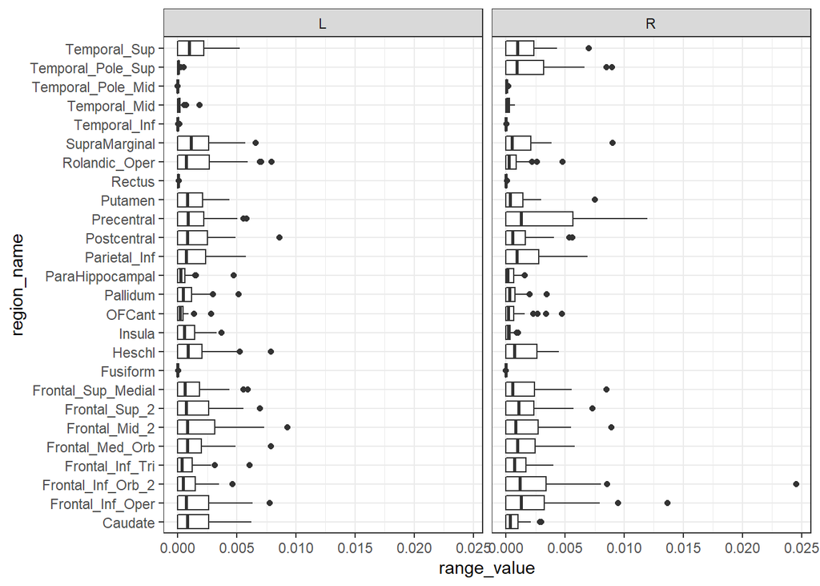

```r
gmd_regional_summary %>%
  filter(!is.infinite(range_value)) %>%
  ggplot(mapping = aes(y = region_name, x = range_value)) +
  geom_boxplot(mapping = aes(group = interaction(region_name, side_name))) +
  facet_wrap(~side_name) +
  theme_bw()
```

rank the people based on the range in the Frontal_Sup_2 region.

```r
people_ranking_order <- gmd_regional_summary %>%
  filter(!is.infinite(range_value)) %>%
  filter(region_name == "Frontal_Sup_2", side_name == "R") %>%
  arrange(desc(range_value)) %>%
  pull(Vault_UID)
```

Look at the top 5 people based on the range in the one region. 901883 has a larger range.

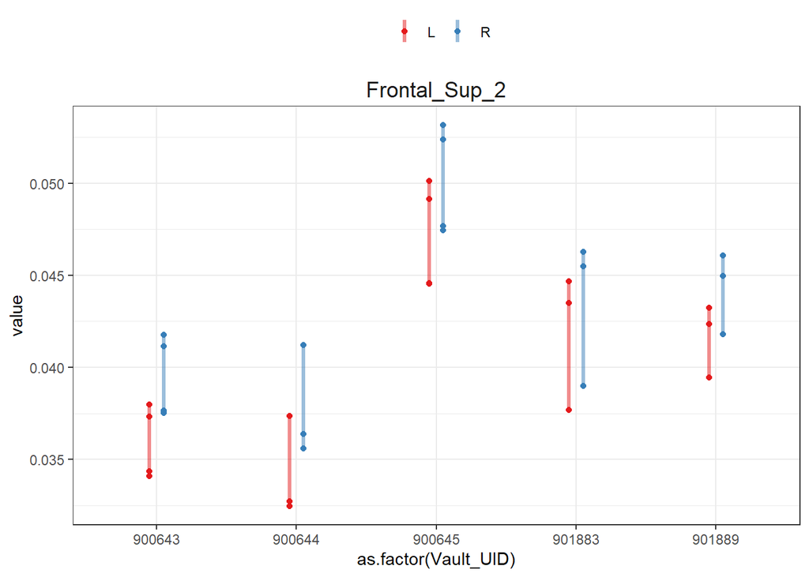

```r
gmd_regional_lf %>%
  filter(region_name %in% 'Frontal_Sup_2') %>%
  filter(Vault_UID %in% people_ranking_order[1:5]) %>%
  ggplot(mapping = aes(x = as.factor(Vault_UID), y = value)) +
  stat_summary(geom = 'linerange',
               fun.min = 'min', fun.max = 'max',
               mapping = aes(group = interaction(Vault_UID,
                                                 region_name,
                                                 side_name),
                             color = side_name),
               position = position_dodge(0.2),
               size = 1.2, alpha = 0.5) +
  geom_point(mapping = aes(group = interaction(Vault_UID,
                                               region_name,
                                               side_name),
                           color = side_name),
             position = position_dodge(0.2)) +
  facet_wrap(~region_name, scales = 'free_y') +
  scale_color_brewer("", palette = "Set1") +
  theme_bw() +
  theme(legend.position = 'top',
        strip.background = element_blank(),
        strip.text = element_text(size = 13.5))
```

Include the average and standard error on the average for each person.

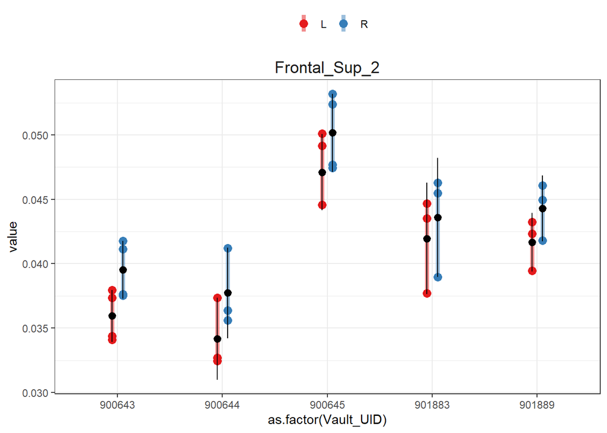

```r
gmd_regional_lf %>%
  filter(region_name %in% 'Frontal_Sup_2') %>%
  filter(Vault_UID %in% people_ranking_order[1:5]) %>%
  ggplot(mapping = aes(x = as.factor(Vault_UID), y = value)) +
  stat_summary(geom = 'linerange',
               fun.min = 'min', fun.max = 'max',
               mapping = aes(group = interaction(Vault_UID,
                                                 region_name,
                                                 side_name),
                             color = side_name),
               position = position_dodge(0.2),
               size = 1.7, alpha = 0.5) +
  geom_point(mapping = aes(group = interaction(Vault_UID,
                                               region_name,
                                               side_name),
                           color = side_name),
             position = position_dodge(0.2),
             size = 3) +
  stat_summary(fun.data = 'mean_se',
               mapping = aes(group = interaction(Vault_UID,
                                                 region_name,
                                                 side_name)),
               fun.args = list(mult = 2),
               color = 'black',
               position = position_dodge(0.2)) +
  facet_wrap(~region_name, scales = 'free_y') +
  scale_color_brewer("", palette = "Set1") +
  theme_bw() +
  theme(legend.position = 'top',
        strip.background = element_blank(),
        strip.text = element_text(size = 13.5))
```

Include the people with the 5 lowest range as well for comparison purposes.

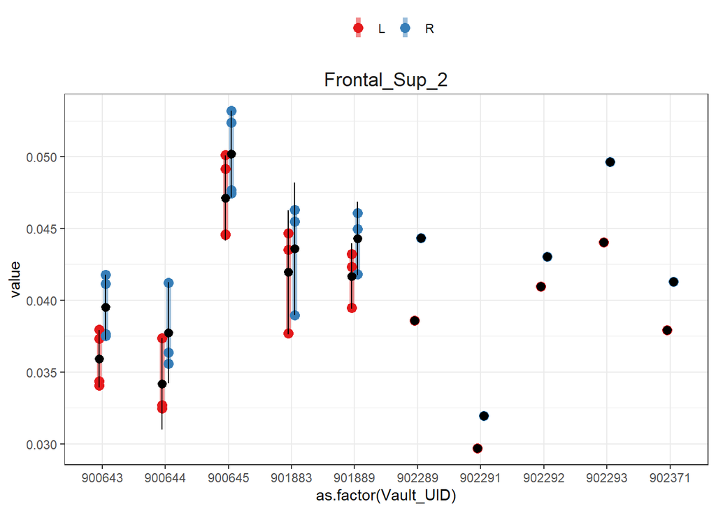

```r
gmd_regional_lf %>%
  filter(region_name %in% 'Frontal_Sup_2') %>%
  filter(Vault_UID %in% c(people_ranking_order[1:5],
                          rev(people_ranking_order)[1:5])) %>%
  ggplot(mapping = aes(x = as.factor(Vault_UID), y = value)) +
  stat_summary(geom = 'linerange',
               fun.min = 'min', fun.max = 'max',
               mapping = aes(group = interaction(Vault_UID,
                                                 region_name,
                                                 side_name),
                             color = side_name),
               position = position_dodge(0.2),
               size = 1.7, alpha = 0.5) +
  geom_point(mapping = aes(group = interaction(Vault_UID,
                                               region_name,
                                               side_name),
                           color = side_name),
             position = position_dodge(0.2),
             size = 3) +
  stat_summary(fun.data = 'mean_se',
               mapping = aes(group = interaction(Vault_UID,
                                                 region_name,
                                                 side_name)),
               fun.args = list(mult = 2),
               color = 'black',
               position = position_dodge(0.2)) +
  facet_wrap(~region_name, scales = 'free_y') +
  scale_color_brewer("", palette = "Set1") +
  theme_bw() +
  theme(legend.position = 'top',
        strip.background = element_blank(),
        strip.text = element_text(size = 13.5))
```